# Election Data: Demographic and Economic Variables with Voting Outcomes

Jonni Johnson

# Introduction

In this report, I include a summary report wherein data were documented at the county level of each state, and describe voter decisions broken down by demographic characteristics, economic trends, and past election patterns. Votes were cast in the 2016 Presidential Election. This report is broken down into separate sections:

- *Data Prepping* - data merging/cleaning steps are described, research questions are identified, and new variables are constructed
- *Data Analyses* - separated by research questions, R syntax is printed to outline analytical steps taken to arrive at each conclusion
- *Data Summary with Visualization* - a general overview is provided as well as a short interpretation of each research question; results are presented in tables and as graphical depictions; additionally, corresponding code to create/manipulate data to accommodate ggplot2 specifications for graphing are included, where applicable

# Data Prepping

Loading data to prepare for merge

```r
cfacts = read.csv("county_facts.csv", sep=",", header = TRUE)
dim(cfacts)
```

```
## [1] 3194   54
```

```r
head(cfacts)
```

```
##   fips      area_name state_abbreviation PST045214 PST040210 PST120214
## 1 1000        Alabama                      4849377   4780127       1.4
## 2 1001 Autauga County                 AL     55395     54571       1.5
## 3 1003 Baldwin County                 AL    200111    182265       9.8
## 4 1005 Barbour County                 AL     26887     27457      -2.1
## 5 1007    Bibb County                 AL     22506     22919      -1.8
## 6 1009  Blount County                 AL     57719     57322       0.7
##   POP010210 AGE135214 AGE295214 AGE775214 SEX255214 RHI125214 RHI225214
## 1   4779736       6.1      22.8      15.3      51.5      69.7      26.7
## 2     54571       6.0      25.2      13.8      51.4      77.9      18.7
## 3    182265       5.6      22.2      18.7      51.2      87.1       9.6
## 4     27457       5.7      21.2      16.5      46.6      50.2      47.6
## 5     22915       5.3      21.0      14.8      45.9      76.3      22.1
## 6     57322       6.1      23.6      17.0      50.5      96.0       1.8
##   RHI325214 RHI425214 RHI525214 RHI625214 RHI725214 RHI825214 POP715213
```

[output cut: 41 more lines]

```r
subcfacts = cfacts[,names(cfacts) %in% c("fips", "area_name", "state_abbreviation", "SEX255214", "POP645213", "EDU635213", "EDU685213", "VET605213","INC110213", "PVY020213", "WTN220207", "RTN130207",  "POP060210")]

colnames(subcfacts) = c("fips", "county", "state", "femalep", "foreignpop", "highscho", "higherscho", "vet", "medhhinc", "povline", "wholesale", "retsale", "popdense")

subcfacts$state = droplevels(subcfacts$state)
subcfacts$county = droplevels(subcfacts$county)

eresults = read.csv("US_County_Level_Presidential_Results_12-16.csv",
                   sep = ",", header = TRUE)
eresults$state_abbr = droplevels(eresults$state_abbr)
eresults$county_name = droplevels(eresults$county_name)
dim(eresults)
```

```
## [1] 3141   18
```

```r
names(eresults)
```

```
##  [1] "FIPS"                "votes_dem_2016"      "votes_gop_2016"
##  [4] "total_votes_2016"    "per_dem_2016"        "per_gop_2016"
##  [7] "diff_2016"           "per_point_diff_2016" "state_abbr"
## [10] "county_name"         "X"                   "total_votes_2012"
## [13] "votes_dem_2012"      "votes_gop_2012"      "per_dem_2012"
## [16] "per_gop_2012"        "diff_2012"           "per_point_diff_2012"
```

To merge the data, each data set must match on at least one column

We chose the column **fips** as both data sets had this same variable

## Cleaning/Merging

```r
colnames(eresults)[colnames(eresults) == "FIPS"] <- "fips"  #relabeled column name to merge
fullelect = merge(subcfacts, eresults, by = "fips")

str(fullelect)  #examine structure of dataframe
```

```
## 'data.frame':    3141 obs. of  30 variables:
##  $ fips               : int  1001 1003 1005 1007 1009 1011 1013 1015 1017 1019 ...
##  $ county             : Factor w/ 1928 levels "Abbeville County",..: 87 94 105 155 170 231 241 254 303 325 ...
##  $ state              : Factor w/ 52 levels "","AK","AL","AR",..: 3 3 3 3 3 3 3 3 3 3 ...
##  $ femalep            : num  51.4 51.2 46.6 45.9 50.5 45.3 53.6 51.8 52.3 50.2 ...
##  $ foreignpop         : num  1.6 3.6 2.9 1.2 4.3 5.4 0.8 2.4 1.1 0.7 ...
##  $ highscho           : num  85.6 89.1 73.7 77.5 77 67.8 76.3 78.6 75.1 78.3 ...
##  $ higherscho         : num  20.9 27.7 13.4 12.1 12.1 12.5 14 16.1 11.8 12.8 ...
##  $ vet                : int  5922 19346 2120 1327 4540 636 1497 11385 2691 2174 ...
##  $ medhhinc           : int  53682 50221 32911 36447 44145 32033 29918 39962 32402 34907 ...
##  $ povline            : num  12.1 13.9 26.7 18.1 15.8 21.6 28.4 21.9 24.1 21.2 ...
##  $ wholesale          : int  0 0 0 0 0 0 56712 0 0 62293 ...
##  $ retsale            : int  598175 2966489 188337 124707 319700 43810 229277 1542981 264650 186321 ...
##  $ popdense           : num  91.8 114.6 31 36.8 88.9 ...
##  $ votes_dem_2016     : int  5908 18409 4848 1874 2150 3530 3716 13197 5763 1524 ...
```

[output cut: 16 more lines]

Dropping some duplicate variables from our set (e.g., the “county_name” column so we don’t use it by accident while doing analysis since it is from the eresults data set and is missing names for multiple counties).

```r
fullelect$county_name<-NULL
fullelect$X <-NULL
fullelect$state <-NULL

str(fullelect)
```

```
## 'data.frame':    3141 obs. of  27 variables:
##  $ fips               : int  1001 1003 1005 1007 1009 1011 1013 1015 1017 1019 ...
##  $ county             : Factor w/ 1928 levels "Abbeville County",..: 87 94 105 155 170 231 241 254 303 325 ...
##  $ femalep            : num  51.4 51.2 46.6 45.9 50.5 45.3 53.6 51.8 52.3 50.2 ...
##  $ foreignpop         : num  1.6 3.6 2.9 1.2 4.3 5.4 0.8 2.4 1.1 0.7 ...
##  $ highscho           : num  85.6 89.1 73.7 77.5 77 67.8 76.3 78.6 75.1 78.3 ...
##  $ higherscho         : num  20.9 27.7 13.4 12.1 12.1 12.5 14 16.1 11.8 12.8 ...
##  $ vet                : int  5922 19346 2120 1327 4540 636 1497 11385 2691 2174 ...
##  $ medhhinc           : int  53682 50221 32911 36447 44145 32033 29918 39962 32402 34907 ...
##  $ povline            : num  12.1 13.9 26.7 18.1 15.8 21.6 28.4 21.9 24.1 21.2 ...
##  $ wholesale          : int  0 0 0 0 0 0 56712 0 0 62293 ...
##  $ retsale            : int  598175 2966489 188337 124707 319700 43810 229277 1542981 264650 186321 ...
##  $ popdense           : num  91.8 114.6 31 36.8 88.9 ...
##  $ votes_dem_2016     : int  5908 18409 4848 1874 2150 3530 3716 13197 5763 1524 ...
##  $ votes_gop_2016     : int  18110 72780 5431 6733 22808 1139 4891 32803 7803 8809 ...
##  $ total_votes_2016   : int  24661 94090 10390 8748 25384 4701 8685 47376 13778 10503 ...
##  $ per_dem_2016       : num  0.2396 0.1957 0.4666 0.2142 0.0847 ...
##  $ per_gop_2016       : num  0.734 0.774 0.523 0.77 0.899 ...
##  $ diff_2016          : int  12202 54371 583 4859 20658 2391 1175 19606 2040 7285 ...
##  $ per_point_diff_2016: num  -0.4948 -0.5779 -0.0561 -0.5554 -0.8138 ...
##  $ state_abbr         : Factor w/ 51 levels "AK","AL","AR",..: 2 2 2 2 2 2 2 2 2 2 ...
##  $ total_votes_2012   : int  23909 84988 11459 8391 23980 5318 9483 46240 14562 9761 ...
##  $ votes_dem_2012     : int  6354 18329 5873 2200 2961 4058 4367 15500 6853 2126 ...
##  $ votes_gop_2012     : int  17366 65772 5539 6131 20741 1250 5081 30272 7596 7494 ...
##  $ per_dem_2012       : num  0.266 0.216 0.513 0.262 0.123 ...
##  $ per_gop_2012       : num  0.726 0.774 0.483 0.731 0.865 ...
##  $ diff_2012          : int  11012 47443 334 3931 17780 2808 714 14772 743 5368 ...
##  $ per_point_diff_2012: num  -0.4606 -0.5582 0.0291 -0.4685 -0.7415 ...
```

### Research Questions

Several demographic and economic variables were considered: education level, presence of foreign born individuals, military status, gender majority by county, merchant and retail sales, percentage of indviduals below the poverty line, and median household income.

To answer whether the above variables were associated with voter outcome, multiple variables were constructed using Base R commands.

## Variable Creation

### Winner Variable

Creating a variable describing final voting outcome for each county:

Final Result (FR) of the election at each county:

```r
fullelect$FR<-""
fullelect$FR[fullelect$per_dem_2016 > fullelect$per_gop_2016] = "Dem"
fullelect$FR[fullelect$per_gop_2016 > fullelect$per_dem_2016] = "Gop"

FRtable <- aggregate(cbind(count = fullelect$FR) ~ fullelect$FR, data = fullelect, FUN = function(x){NROW(x)})

names(FRtable)[1] <- "County Outcome"

FRtable
```

```
##   County Outcome count
## 1            Dem   488
## 2            Gop  2653
```

*Coloring*

For this markdown, red palettes refer to Republican/GOP outcomes and blue palettes refer to Democratic:

```r
FRpalette <- c('navyblue', 'firebrick4') #creating a corresponding color palette to use later in graphing
FRpalletelite <- c("dodgerblue2", "firebrick1")
```

### Education Variable

Creating variables so that education levels can be divided into three categories 1. Percent without high school diploma 2. Percent with high school diploma but no higher level education 3. Percent with higher education (bachelor’s or higher)

```r
#1
fullelect$without_high_school_diploma<-100-fullelect$highscho

#2
fullelect$high_school_education<-fullelect$highscho-fullelect$higherscho

#3
fullelect$higher_education<-fullelect$higherscho

colnames(fullelect)
```

```
##  [1] "fips"                        "county"
##  [3] "femalep"                     "foreignpop"
##  [5] "highscho"                    "higherscho"
##  [7] "vet"                         "medhhinc"
##  [9] "povline"                     "wholesale"
## [11] "retsale"                     "popdense"
## [13] "votes_dem_2016"              "votes_gop_2016"
## [15] "total_votes_2016"            "per_dem_2016"
## [17] "per_gop_2016"                "diff_2016"
## [19] "per_point_diff_2016"         "state_abbr"
## [21] "total_votes_2012"            "votes_dem_2012"
## [23] "votes_gop_2012"              "per_dem_2012"
## [25] "per_gop_2012"                "diff_2012"
## [27] "per_point_diff_2012"         "FR"
## [29] "without_high_school_diploma" "high_school_education"
## [31] "higher_education"
```

```r
summary(fullelect[,29:31])
```

```
##  without_high_school_diploma high_school_education higher_education
##  Min.   : 1.00               Min.   :21.6          Min.   : 3.20
##  1st Qu.:10.20               1st Qu.:61.2          1st Qu.:13.70
##  Median :14.10               Median :65.8          Median :17.60
##  Mean   :15.45               Mean   :64.8          Mean   :19.75
##  3rd Qu.:19.80               3rd Qu.:69.9          3rd Qu.:23.50
##  Max.   :55.00               Max.   :83.0          Max.   :74.40
```

```r
#Assess that each adds to 100
edu.check<-fullelect$high_school_education+fullelect$higher_education+fullelect$without_high_school_diploma

summary(edu.check)
```

```
##    Min. 1st Qu.  Median    Mean 3rd Qu.    Max.
##     100     100     100     100     100     100
```

```r
edu.check<-grepl(100,edu.check)
all(edu.check)
```

```
## [1] TRUE
```

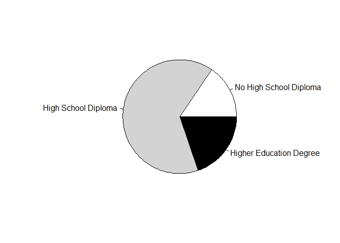

```r
pct <- c(15.45, 64.8, 19.75)  #Graphing mean percentages of total voters
shades <- c("white", "lightgrey", "black")
categories <- c("No High School Diploma", "High School Diploma", "Higher Education Degree")



pie(pct, labels = categories, col = shades)
```

### Gender Majority Variable

Creating a variable to indicate the gender majority of each county

```r
fullelect <- cbind(fullelect, gendom = "female")

fullelect$gendom <- factor(fullelect$gendom, levels = c("female", "male"))

fullelect$gendom[fullelect$femalep < 50] <- "male"

table(fullelect$gendom)
```

```
##
## female   male
##   2018   1123
```

### Population Density in levels Variable

Re-classifying the population density variable to be in levels based on the national average, and above/below the 1st and 3rd quartiles.

1. First a summary statistics was called to identify level breaks

```r
summary(fullelect$popdense)
```

```
##    Min. 1st Qu.  Median    Mean 3rd Qu.    Max.
##     0.0    16.9    45.2   259.2   113.6 69467.5
```

2. A new factor variable was constructed describing the county’s density with regards to the national median (i.e., 45.2 people per sq mile)

```r
fullelect <- cbind(fullelect, dense = "")

fullelect$dense <- factor(fullelect$dense, levels = c("strongly less dense", "mildly less dense", "mildly more dense", "strongly more dense"))

fullelect$dense[fullelect$popdense < 16.9 ] <- "strongly less dense"

fullelect$dense[fullelect$popdense > 16.9 ] <- "mildly less dense"

fullelect$dense[fullelect$popdense > 45.2 ] <- "mildly more dense"

fullelect$dense[fullelect$popdense > 113.6 ] <- "strongly more dense"


table(fullelect$dense)
```

```
##
## strongly less dense   mildly less dense   mildly more dense
##                 783                 786                 784
## strongly more dense
##                 785
```

### Shifting Blue to Red Variable

Creating variables that consider how the county voted in 2012 compared to 2016, differences in percentage of vote for democratic party, at 5 levels of Democratic Vote changes from 2012-2016: Mild Blue Shift, Mild Red Shift, Moderate Red Shift, Strong Red Shift, Severe Red Shift

1. First a numeric difference variable was constructed (e.g., negative scores indicated greater Democratic percentage of the vote in 2016 compared to 2012)
2. Summary statistics defined the bounderies of each of the levels, mainly capturing the data around the mean and between the 1st and 3rd quartile of the data

```r
fullelect$demshift <- fullelect$per_dem_2012 - fullelect$per_dem_2016  # numeric shift variable

summary(fullelect$demshift)  #29 NA's due to missing 2012 data from ALASKA counties
```

```
##     Min.  1st Qu.   Median     Mean  3rd Qu.     Max.     NA's
## -0.09346  0.03353  0.06295  0.06787  0.10209  0.23445       29
```

3. Create a categorical variable using the summary statistic boundaries

```r
fullelect <- cbind(fullelect, demmoreless = "")

fullelect$demmoreless <- factor(fullelect$demmoreless, levels = c("Mild Blue Shift", "Mild Red Shift", "Moderate Red Shift", "Strong Red Shift", "Severe Red Shift"))

fullelect$demmoreless[fullelect$demshift < 0 ] <- "Mild Blue Shift"

fullelect$demmoreless[fullelect$demshift > 0 ] <- "Mild Red Shift" #includes just beyond 1st quartile limit to include all data

fullelect$demmoreless[fullelect$demshift > 0.03353] <- "Moderate Red Shift"

fullelect$demmoreless[fullelect$demshift > 0.06788] <- "Strong Red Shift"

fullelect$demmoreless[fullelect$demshift > 0.10210 ] <- "Severe Red Shift"


str(fullelect$demmoreless)
```

```
##  Factor w/ 5 levels "Mild Blue Shift",..: 2 2 3 3 3 2 2 3 3 4 ...
```

```r
table(fullelect$demmoreless)
```

```
##
##    Mild Blue Shift     Mild Red Shift Moderate Red Shift
##                212                566                872
##   Strong Red Shift   Severe Red Shift
##                684                778
```

# Data Analyses

## Demographic Questions

### Question 1

*Is there a relation between education level and election outcome?*

```r
edu<-aggregate(cbind(fullelect$higher_education,fullelect$high_school_education,fullelect$without_high_school_diploma)~fullelect$FR,FUN = "mean")
names(edu)[1]="Party"
names(edu)[2]="College Degree or Higher"
names(edu)[3]="High School Diploma Only"
names(edu)[4]="No High School Diploma"

edu
```

```
##   Party College Degree or Higher High School Diploma Only
## 1   Dem                 27.95369                 56.36619
## 2   Gop                 18.24542                 66.34926
##   No High School Diploma
## 1               15.68012
## 2               15.40531
```

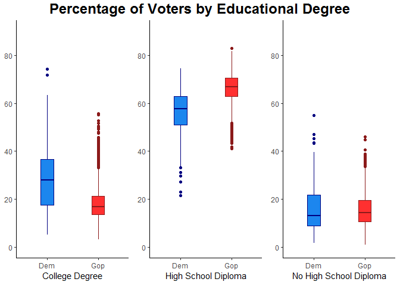

| Dominant Party | College Degree or Higher | High School Diploma Only | No High School Diploma |
| --- | --- | --- | --- |
| Democratic | 27.95369 | 56.36619 | 15.68012 |
| Republican | 18.24542 | 66.34926 | 15.40531 |

```r
library(ggplot2)
library(gridExtra)
library(grid)
library(lattice)

ghighered <- ggplot(fullelect, aes(x = FR, y = higher_education)) +
           geom_boxplot(color = FRpalette, fill = FRpalletelite, width = .25) +
           scale_x_discrete(name = "College Degree") +
           scale_y_continuous(breaks=c(0, 20, 40, 60, 80), limits = c(0,90), name = NULL) +
           theme_classic()

ghighed <- ggplot(fullelect, aes(x = FR, y = high_school_education)) +
           geom_boxplot(color = FRpalette, fill = FRpalletelite, width = .25) +
           scale_x_discrete(name = "High School Diploma") +
           scale_y_continuous(breaks=c(0, 20, 40, 60, 80), limits = c(0,90), name = NULL) +
           theme_classic()

gnohighed <- ggplot(fullelect, aes(x = FR, y = without_high_school_diploma)) +
           geom_boxplot(color = FRpalette, fill = FRpalletelite, width = .25) +
           scale_x_discrete(name = "No High School Diploma") +
           scale_y_continuous(breaks=c(0, 20, 40, 60, 80), limits = c(0,90), name = NULL) +
            theme_classic()

title1=textGrob("Percentage of Voters by Educational Degree", gp=gpar(fontface="bold", fontsize = 18))

 grid.arrange(ghighered, ghighed, gnohighed, ncol = 3, nrow = 1, top =title1)
```

- Greater percentage of people with higher education degrees appears to be associated with voting Democratic. Whereas the bulk of Republican swaying counties have greater percentages of High School Diploma Only or less.

### Question 2

*Is there a relation between percent of foreign born persons in a county and the election outcome?*

```r
foreign<-aggregate(fullelect$foreignpop~fullelect$FR,FUN = "mean")
names(foreign)[1]="Party"
names(foreign)[2]="Percentage of Foreign Born County Residents"
foreign
```

```
##   Party Percentage of Foreign Born County Residents
## 1   Dem                                     9.41168
## 2   Gop                                     3.62009
```

```r
summary(fullelect$foreignpop)
```

```
##    Min. 1st Qu.  Median    Mean 3rd Qu.    Max.
##    0.00    1.20    2.50    4.52    5.60   56.60
```

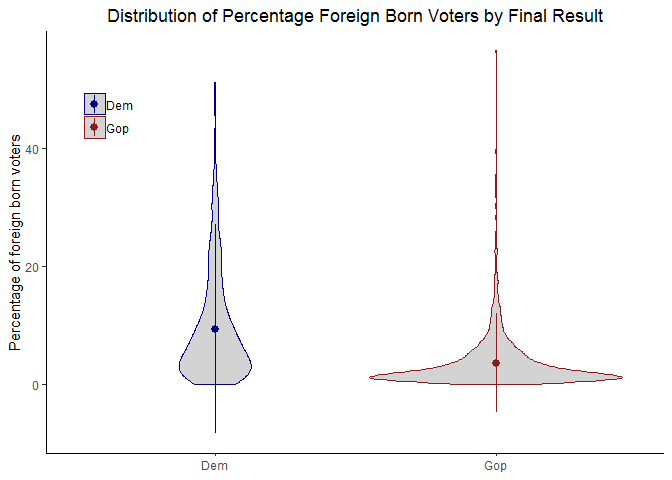

| Dominant Party | Average % Foreign Born Personsin a county |
| --- | --- |
| Democratic | 9.41168 |
| Republican | 3.62009 |

```r
  ggplot(fullelect, aes(x = FR, y = foreignpop, color = FR)) +
               geom_violin(trim = T, fill = 'lightgrey') +
    stat_summary(fun.data="mean_sdl", geom = "pointrange") +
    scale_color_manual(values = FRpalette) +
                 scale_y_continuous(name="Percentage of foreign born voters") +
               scale_x_discrete(name=NULL) +
               ggtitle("Distribution of Percentage Foreign Born Voters by Final Result") +
    theme_classic() +
    theme(legend.title =element_blank(), plot.title = element_text(hjust = .5)) +
    theme(legend.position = c(.1, .8))
```

- Counties where the democratics won on average have higher percentages of foreign born persons. While both are skewed in distribution, many of the counties voting republican have less than 5% representation of foreign born citizens

```r
table(fullelect$FR, fullelect$foreignpop <= 5)
```

```
##
##       FALSE TRUE
##   Dem   285  203
##   Gop   581 2072
```

### Question 3

*Is there a relation between number of veterans in a county and the election outcome?*

```r
vetsum <- tapply(fullelect$vet, fullelect$FR, sum)
vetsum
```

```
##      Dem      Gop
##  9700890 11562245
```

```r
library(scales)

vetsum3 <- tapply(fullelect$vet, list(fullelect$FR, fullelect$demmoreless), sum)
vetsum3
```

```
##     Mild Blue Shift Mild Red Shift Moderate Red Shift Strong Red Shift
## Dem         4598673        3095515            1210601           625142
## Gop         1403229        2798007            3319783          2183694
##     Severe Red Shift
## Dem           170959
## Gop          1786528
```

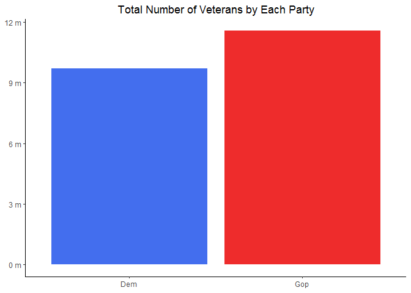

| Dominant Party | Number of Veterans across all counties |
| --- | --- |
| Democratic | 9,700,890 |
| Republican | 11,562,245 |

```r
fullvet <- ggplot(fullelect) +
           stat_summary(aes(x = FR, y = vet), fun.y=sum, geom = "bar", fill = c("royalblue2", "firebrick2"))
fullvet2 <- fullvet +
            labs(x = NULL, y = NULL) +
            ggtitle("Total Number of Veterans by Each Party") +
            theme(plot.title =element_text(size = 16, face = "bold", hjust = 1),
             axis.text.x = element_text(size = 5),
             axis.text.y = element_text(size = 5),
             axis.title.x = element_text(size = 12),
             axis.title.y = element_text(size = 12)) +
             theme_classic() +
  theme(plot.title = element_text(hjust = .5)) +
  scale_y_continuous(label = unit_format(unit = "m", scale = 1e-6))

fullvet2
```

We might conclude that in general, veterans voted republican

But when we examine this while considering changing political opinions:

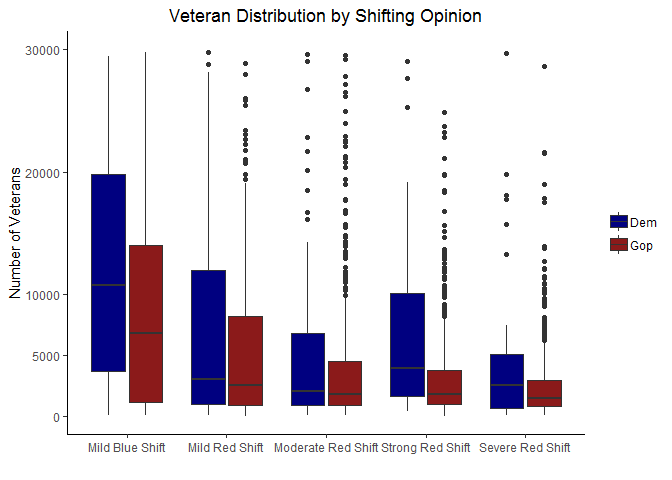

```r
vet1 <- ggplot(na.omit(fullelect), aes(x = demmoreless, y = vet, fill= FR))

vet2 <- vet1 + geom_boxplot() +
        scale_fill_manual(values = FRpalette) +
        scale_x_discrete(name = "") +
        scale_y_continuous(name = "Number of Veterans", limits = c(0, 30000),
                          breaks = c(0,5000, 10000, 20000, 30000)) +
        labs(title = "Veteran Distribution by Shifting Opinion")


 vet2 + theme_classic() +
         theme(legend.title = element_blank()) +
   theme(plot.title = element_text(hjust = .5))
```

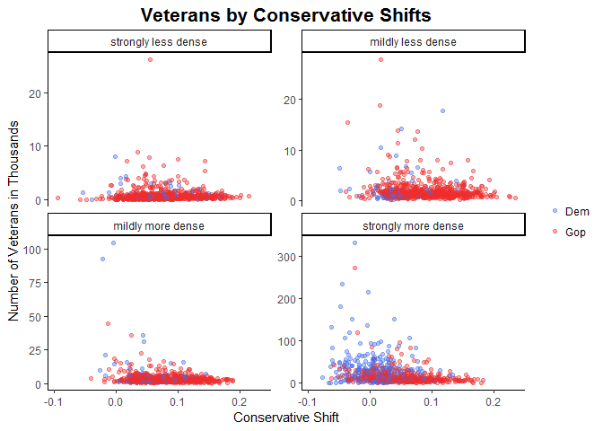

| Dominant Party | Mild Blue Shift | Mild Red Shift | Moderate Red Shift | Strong Red Shift | Severe Red Shift |
| --- | --- | --- | --- | --- | --- |
| Democratic | 4,598,673 | 3,095,515 | 1,210,601 | 625,142 | 170,959 |
| Republican | 1,403,229 | 2,798,007 | 3,319,783 | 2,183,694 | 1,786,528 |

```r
ggplot(na.omit(fullelect), aes(x = demshift, y = vet/1000, color = FR)) + geom_point(alpha = .4) +
 facet_wrap(~dense, scales = "free_y") +
            scale_color_manual(values = c("royalblue2", "firebrick2")) +
            labs(x = "Conservative Shift", y = "Number of Veterans in Thousands") +
            ggtitle("Veterans by Conservative Shifts") +
            theme_classic() +
            theme(plot.title =element_text(size = 16, face = "bold", hjust = .5)) +
            theme(legend.title = element_blank())
```

- It appears that, when counties were leaning more democratic or experienced the weakest shift from blue to red, more veterans voted democratic; however, when counties were leaning more republican, greater number of veterans were observed among counties who went Republican. This seemed to be related as well to the population density of the area. Wherein, areas with mild blue or mild red shifts in opinion had greater veterans voting democrat than republican, particularly in densely populated areas

## Economic Questions

Questions 4 and 5 considered Merchant and Retail sales, respectively. Results are presented together for bigger picture take-away

### Question 4

*Is there a relation between value of merchant wholesaler county sales and the election outcome?* Table Syntax

```r
A=aggregate(fullelect$wholesale~fullelect$FR,FUN = "mean")
names(A)[1]="Party"
names(A)[2]="Mean Wholesale Value (1000$)"
A
```

```
##   Party Mean Wholesale Value (1000$)
## 1   Dem                    5662055.9
## 2   Gop                     392957.8
```

```r
A1 <- tapply(fullelect$wholesale, list(fullelect$FR, fullelect$dense), mean)

A1
```

```
##     strongly less dense mildly less dense mildly more dense
## Dem            26379.97          79090.65          744395.3
## Gop            55112.80          94683.56          146693.9
##     strongly more dense
## Dem            10041393
## Gop             1611604
```

Graphing Syntax

```r
Aplot <- ggplot(fullelect) +
           stat_summary(aes(x = FR, y = wholesale), fun.y=mean, geom = "bar", fill = c("royalblue2", "firebrick2")) +
            labs(x = "", y = "Amount of Merchant Wholesales in Millions") +
            ggtitle("Merchant Wholesales") +
            theme_classic() +
            theme(plot.title =element_text(size = 16, face = "bold", hjust = .5)) +
            scale_y_continuous(label = unit_format(unit = "m", scale = 1e-6))
```

- Considering Density of Area

```r
tmpAleastdense <- fullelect[fullelect$dense =="strongly less dense",]
Aleast <- ggplot(na.omit(tmpAleastdense)) +
           stat_summary(aes(x = FR, y = wholesale), fun.y=mean, geom = "bar", fill = c("royalblue2", "firebrick2")) +
             labs(x = "Strongly Less", y = "Amount of Merchant Wholesales in Millions") +
            theme_classic() +
             theme(plot.title =element_text(size = 16, face = "bold", hjust = .5))


tmpAlessdense <- fullelect[fullelect$dense =="mildly less dense",]

Aless <- ggplot(na.omit(tmpAlessdense)) +
           stat_summary(aes(x = FR, y = wholesale), fun.y=mean, geom = "bar", fill = c("royalblue2", "firebrick2")) +
             labs(x = "Mildly Less", y = NULL) +
              theme_classic() +
             theme(plot.title =element_text(size = 16, face = "bold", hjust = .5))


tmpAmoredense <- fullelect[fullelect$dense =="mildly more dense",]
Amore <- ggplot(na.omit(tmpAmoredense)) +
           stat_summary(aes(x = FR, y = wholesale), fun.y=mean, geom = "bar", fill = c("royalblue2", "firebrick2")) +
             labs(x = "Mildly More", y = NULL) +
              theme_classic() +
             theme(plot.title =element_text(size = 16, face = "bold", hjust = .5))



tmpAmostdense <- fullelect[fullelect$dense =="strongly more dense",]

Amost <- ggplot(na.omit(tmpAmostdense)) +
           stat_summary(aes(x = FR, y = wholesale), fun.y=mean, geom = "bar", fill = c("royalblue2", "firebrick2")) +
             labs(x = "Strongly More", y = NULL) +
              theme_classic() +
             theme(plot.title =element_text(size = 16, face = "bold", hjust = .5))
```

### Question 5

*Is there a relation between value of retail county sales and the election outcome?*

```r
B=aggregate(fullelect$retsale~fullelect$FR,FUN = "mean")
names(B)[1]="Party"
names(B)[2]="Mean Retail Sales Value (1000$)"
B
```

```
##   Party Mean Retail Sales Value (1000$)
## 1   Dem                         4554350
## 2   Gop                          637637
```

```r
B1 <- tapply(fullelect$retsale , list(fullelect$FR, fullelect$dense), mean)
B1
```

```
##     strongly less dense mildly less dense mildly more dense
## Dem           145828.68          373378.6         1359407.8
## Gop            96647.82          208089.2          461970.6
##     strongly more dense
## Dem             7750199
## Gop             2221097
```

```r
Bplot <- ggplot(fullelect) +
           stat_summary(aes(x = FR, y = retsale), fun.y=mean, geom = "bar", fill = c("royalblue2", "firebrick2"))
Bplot2 <- Bplot +
            labs(x = "", y = "Amount of Retail Sales") +
            ggtitle("Merchant Retail Sales") +
            theme_classic() +
            theme(plot.title =element_text(size = 16, face = "bold", hjust = .5)) +
            scale_y_continuous(label = unit_format(unit = "m", scale = 1e-6))
```

- Considering areas’ density here as well

```r
Bleast <- ggplot(na.omit(tmpAleastdense)) +
           stat_summary(aes(x = FR, y = retsale), fun.y=mean, geom = "bar", fill = c("royalblue2", "firebrick2")) +
             labs(x = "Strongly Less", y = "Amount of Merchant Retail Sales") +
              theme_classic() +
             theme(plot.title =element_text(size = 16, face = "bold", hjust = .5))


Bless <- ggplot(na.omit(tmpAlessdense)) +
           stat_summary(aes(x = FR, y = retsale), fun.y=mean, geom = "bar", fill = c("royalblue2", "firebrick2")) +
             labs(x = "Mildly Less", y = NULL) +
              theme_classic() +
             theme(plot.title =element_text(size = 16, face = "bold", hjust = .5))


Bmore <- ggplot(na.omit(tmpAmoredense)) +
           stat_summary(aes(x = FR, y = retsale), fun.y=mean, geom = "bar", fill = c("royalblue2", "firebrick2")) +
             labs(x = "Mildly More", y = NULL) +
              theme_classic() +
             theme(plot.title =element_text(size = 16, face = "bold", hjust = .5))


Bmost <- ggplot(na.omit(tmpAmostdense)) +
           stat_summary(aes(x = FR, y = retsale), fun.y=mean, geom = "bar", fill = c("royalblue2", "firebrick2")) +
             labs(x = "Strongly More", y = NULL) +
             theme_classic() +
             theme(plot.title =element_text(size = 16, face = "bold", hjust = .5))
```

#### *Is there a relation between a county’s commerce and the election outcome?*

| Dominant Party | Whole Sale | Retail Sale |
| --- | --- | --- |
| Democratic | 5,662,055.90 | 4,554,350 |
| Republican | 392,957.80 | 637,637 |

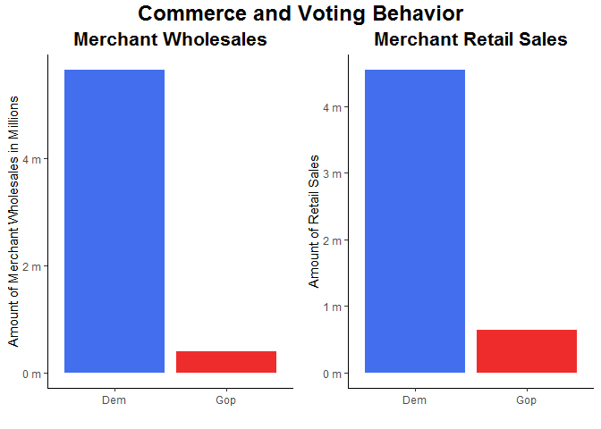

```r
title2=textGrob("Commerce and Voting Behavior", gp=gpar(fontface="bold", fontsize = 18))

 grid.arrange(Aplot, Bplot2, ncol = 2, nrow = 1, top =title2)
```

- As it can be seen, the counties with higher level of whole and retail sale values tend to vote Democratic while those with less whole and retail sale portions tend to vote Republican.
- Considering density, counties leaned Repulican when of lower density and doing better in Whole sale compared to Democratic leaning counties at the same density level. Yet as denisty increased, so did trade as did county tendency to vote Democratic.

Whole Sale

| Dominant Party | Strongly less dense | Mildly less dense | Mildly more dense | Strongly more dense |
| --- | --- | --- | --- | --- |
| Democratic | 26,379.97 | 79,090.65 | 744,395.30 | 10,041,393 |
| Republican | 55,112.80 | 94,683.56 | 146,693.90 | 1,611,604 |

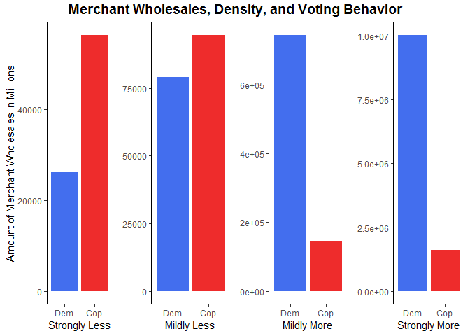

```r
title3=textGrob("Merchant Wholesales, Density, and Voting Behavior", gp=gpar(fontface="bold", fontsize = 14))

 grid.arrange(Aleast, Aless, Amore, Amost, ncol = 4, nrow = 1, top =title3)
```

Retail Sale

| Dominant Party | Strongly less dense | Mildly less dense | Mildly more dense | Strongly more dense |
| --- | --- | --- | --- | --- |
| Democratic | 145,828.68 | 373,378.60 | 1,359,407.80 | 7,750,199.00 |
| Republican | 96,647.82 | 208,089.20 | 461,970.60 | 2,221,097.00 |

- Similarly in retail sales, when considering the density of the county compared to the national density average, as density increases, the disparity in the amount of retail sales between Democratic and Republican leaning counties increases.

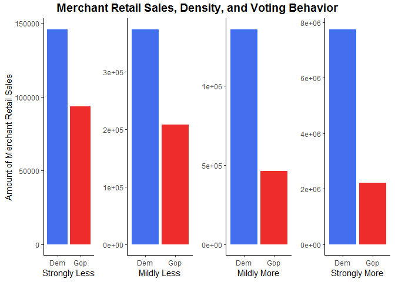

```r
title4=textGrob("Merchant Retail Sales, Density, and Voting Behavior", gp=gpar(fontface="bold", fontsize = 14))

 grid.arrange(Bleast, Bless, Bmore, Bmost, ncol = 4, nrow = 1, top =title4)
```

- Overall, counties exhibiting greater economic hardship with lower levels of retail sale tended to vote Republican.

### Question 6

*Is there a relation between percentage of people living below the poverty line, gender majority, and election outcome?*

```r
pov <- tapply(fullelect$povline, list(fullelect$FR, fullelect$gendom), mean)
pov
```

```
##       female     male
## Dem 19.10701 19.82479
## Gop 16.56970 15.59543
```

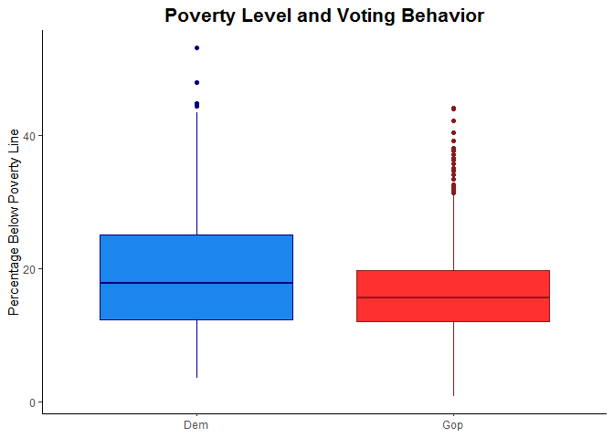

```r
povplot <- ggplot(fullelect, aes(x = FR, y = povline)) +
            geom_boxplot(fill = FRpalletelite, color = FRpalette) +
            labs(x = NULL, y = "Percentage Below Poverty Line") +
             ggtitle("Poverty Level and Voting Behavior") +
             theme_classic() +
            theme(plot.title =element_text(size = 16, face = "bold", hjust = .5)) +
              theme(legend.title = element_blank())
povplot
```

- Counties that went Democratic tended to have a higher percentage of people living below the poverty line

| Dominant Party | Female Majority | Male Majority |
| --- | --- | --- |
| Democratic | 19.10701 | 19.82479 |
| Republican | 16.56970 | 15.59543 |

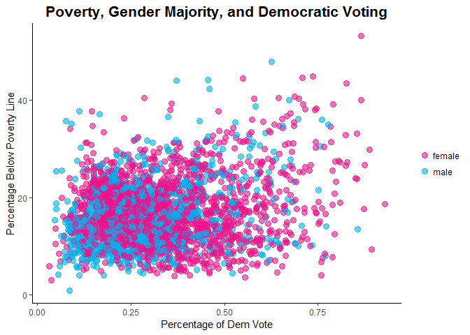

```r
povplot2 <- ggplot(fullelect, aes(x = per_dem_2016, y = povline, color = gendom)) +
            geom_point(size = 3, alpha = 0.6) +
            scale_color_manual(values = c("deeppink2", "deepskyblue2"))

povplot3 <-  povplot2 +  labs(x = "Percentage of Dem Vote", y = "Percentage Below Poverty Line") +
             #scale_color_manual(values = c("darkorchid3", "chocolate3")) +
             ggtitle("Poverty, Gender Majority, and Democratic Voting") +
              theme_classic() +
              theme(plot.title =element_text(size = 16, face = "bold", hjust = .5)) +
              theme(legend.title = element_blank())

povplot3
```

- The gender majority did not seem to affect the influence poverty percentage had on voter outcome

### Question 7

*Is there a relation between median income amount and changing political opinions?*

```r
medinc <- tapply(fullelect$medhhinc, fullelect$demmoreless, mean)
medinc
```

```
##    Mild Blue Shift     Mild Red Shift Moderate Red Shift
##           61197.61           48296.44           43577.97
##   Strong Red Shift   Severe Red Shift
##           43953.82           43824.67
```

```r
#Considering Gender Majority

medincgen <- tapply(fullelect$medhhinc, list(fullelect$demmoreless, fullelect$gendom), mean)
medincgen
```

```
##                      female     male
## Mild Blue Shift    62765.81 57130.93
## Mild Red Shift     47889.97 49476.61
## Moderate Red Shift 43820.07 43043.92
## Strong Red Shift   43288.16 45094.94
## Severe Red Shift   42971.00 44780.70
```

| Political Opinion Change | Female Majority | Male Majority |
| --- | --- | --- |
| Mild Blue Shift | 62,765.81 | 57,130.93 |
| Mild Red Shift | 47,889.97 | 49,476.61 |
| Moderate Red Shift | 43,820.07 | 43,043.92 |
| Strong Red Shift | 43,288.16 | 45,094.94 |
| Severe Red Shift | 42,971.00 | 44,780.70 |

- Counties that increased in percentage of Democratic votes from 2012-2016 exhibited higher median incomes, particularly in female majority counties.
- The median income is $44,160.00; unsupringly, counties where the average median income is below the national average show an increase in shifting away from Democratic votes and toward voting Republican
- It is possible that the shift observed in percentage of Democratic votes is from frustration at stale economic growth; whereas counties that are well above the average show a preference to permit Democratics to stay in control.

# Data Summary

Demographic characteristics, economic trends, and prior voting behavior were considered in the analyses reported. Our analyses have come to four broad conclusions regarding who voted Republican versus Democratic:

1. Arguably, less exposure to diversity (i.e., by way of foreign born neighbor or higher education) was associated with greater tendency to vote Republican
2. Veterans heavily contributed to the county vote going republican, when the county was moderately shifting (or greater) in favor of Republican. This however was not the case in densely populated areas; here, the trend was reversed with more veterans populating democratic leaning counties
3. Counties, particularly as population density increased, in which economic conditions of the community have been better in terms of commerce tend to vote Democratic.
4. The socio-economic analyses together seem to indicate that counties, particularly female majority counties, that were better off (i.e., higher median income) or had greater percentage of individuals below the poverty line tended to vote democratic. It appears as those the individual in the middle, neither experience too much hardship or any economic growth, exhibit a shift in voting preference, prefering the Republican party, especially in lesser, densly populated areas.